# Multiple Comparisons

Проблема множественных сравнений

Matvei Slavenko / Матвей Славенко

02.07.2022

# Часть 1. Разминка

# Данные. Генеральная совокупность

Файл `soccer.csv`.

Данные о футболистах: имя, позиция на поле (защитник, форвард, голкипер или полузащитник), гражданство, возраст и рост.

```r
soccer_general <- read.csv("soccer.csv", sep=";")[, 2:6] %>%
  mutate(Position = as.factor(Position),
         Nationality = as.factor(Nationality),
         Age = as.numeric(Age),
         Height = as.numeric(Height)) %>%
  filter(Nationality %in% c("Spanish", "Italian", "German", "English", "Argentinian"))
```

# Данные. Наша рабочая выборка

```r
set.seed(1)

soccer_wrk <- soccer_general[sample(1:nrow(soccer_general), 50), ] %>%
  mutate(Nationality = factor(Nationality))


soccer_wrk %>% head
```

```
##                      Name   Position Nationality Age Height
## 1017 Antonio Floro Flores    Forward     Italian  28    182
## 679   Ángel Lafita Midfielder     Spanish  27    188
## 129     Michael Mancienne   Defender     English  23    184
## 930           Marco Motta   Defender     Italian  25    186
## 471      Andres Fernandez Goalkeeper     Spanish  24    183
## 299          Gareth Barry Midfielder     English  30    181
```

*Не совсем корректно, конечными генеральными совокупностями занимается не классическая статистика, а sample surveys. Но для сегодняшних целей пойдет.*

# Данные – сводка

```r
soccer_wrk %>% summary
```

```
##      Name                 Position       Nationality      Age
##  Length:50          Defender  :18   Argentinian: 7   Min.   :19.0
##  Class :character   Forward   :16   English    :11   1st Qu.:24.0
##  Mode  :character   Goalkeeper: 5   German     : 6   Median :27.0
##                     Midfielder:11   Italian    :11   Mean   :26.9
##                                     Spanish    :15   3rd Qu.:30.0
##                                                      Max.   :37.0
##      Height
##  Min.   :165.0
##  1st Qu.:179.0
##  Median :183.0
##  Mean   :183.2
##  3rd Qu.:188.0
##  Max.   :201.0
```

# Сфокусируемся на возрасте защитников (Defenders)

```r
soccer_wrk %>% filter(Position == "Defender") %>% pull(Age) %>% summary
```

```
##    Min. 1st Qu.  Median    Mean 3rd Qu.    Max.
##   19.00   23.25   26.00   26.28   29.75   34.00
```

# Разминка 1. Тестирование

Средний возраст защитника в генеральной совокупности:

```r
soccer_general %>% filter(Position == "Defender") %>% pull(Age) %>% mean(na.rm = TRUE)
```

```
## [1] 26.88427
```

Как протестировать гипотезу $H0: \mu = 26.88$?

```r
soccer_wrk %>% filter(Position == "Defender") %>% select(Age) %>% t.test(mu = 26.88)
```

```
##
##  One Sample t-test
##
## data:  .
## t = -0.65891, df = 17, p-value = 0.5188
## alternative hypothesis: true mean is not equal to 26.88
## 95 percent confidence interval:
##  24.34948 28.20607
## sample estimates:
## mean of x
##  26.27778
```

# Разминка 2. Типы ошибок

Какие два типа ошибок мы можем допустить при тестировании гипотез?

# Разминка 2. Типы ошибок

Какие два типа ошибок мы можем допустить при тестировании гипотез?

|  | H0 holds | H0 does not hold |
| --- | --- | --- |
| H0 rejected | Type I error | OK |
| H0 not rejected | OK | Type II error |

# Разминка 2. Типы ошибок

|  | H0 holds | H0 does not hold |
| --- | --- | --- |
| H0 rejected | Type I error | OK |
| H0 not rejected | OK | Type II error |

1. Можем ли мы контролировать ошибку первого типа?
2. А ошибку второго типа?

# Разминка 2. Типы ошибок

|  | H0 holds | H0 does not hold |
| --- | --- | --- |
| H0 rejected | Type I error | OK |
| H0 not rejected | OK | Type II error |

- Можем ли мы контролировать ошибку первого типа?
  - => да, выбираем $\alpha$ => Comparison-wise Error Rate
- А ошибку второго типа?
  - => косвенно, через увеличение размера выборки
  - => power analysis

# Разминка 3. Доверительные интервалы

p-value – это здорово, но нам бы хотелось иметь более детальное представление о среднем возрасте защитников.

```r
soccer_wrk %>% filter(Position == "Defender") %>% pull(Age) %>% t.test(mu = 26.88)
```

```
##
##  One Sample t-test
##
## data:  .
## t = -0.65891, df = 17, p-value = 0.5188
## alternative hypothesis: true mean is not equal to 26.88
## 95 percent confidence interval:
##  24.34948 28.20607
## sample estimates:
## mean of x
##  26.27778
```

- Что такое 95% доверительный интервал?

# Разминка 3. Доверительные интервалы

p-value – это здорово, но нам бы хотелось иметь более детальное представление о среднем возрасте защитников.

```r
soccer_wrk %>% filter(Position == "Defender") %>% pull(Age) %>% t.test
```

```
##
##  One Sample t-test
##
## data:  .
## t = 28.751, df = 17, p-value = 7.426e-16
## alternative hypothesis: true mean is not equal to 0
## 95 percent confidence interval:
##  24.34948 28.20607
## sample estimates:
## mean of x
##  26.27778
```

- Что такое 95% доверительный интервал?
  - Это процедура
  - Процедура на основе данных (= выборки) генерирует интервал
  - При многократном повторении эксперимента, сгененерированный интервал в 95% процентов случаев покроет среднее генеральной совокупности.

# Разминка 3. Доверительные интервалы

p-value – это здорово, но нам бы хотелось иметь более детальное представление о среднем возрасте защитников.

- Что такое 95% доверительный интервал?
  - Это процедура
  - Процедура на основе данных (= выборки) генерирует интервал
  - При многократном повторении эксперимента, сгененерированный интервал в 95% процентов случаев покроет среднее генеральной популяции.
- Бывают ли интервалы не для среднего?

# Разминка 3. Доверительные интервалы

p-value – это здорово, но нам бы хотелось иметь более детальное представление о среднем возрасте защитников.

- Что такое 95% доверительный интервал?
  - Это процедура
  - Процедура на основе данных (= выборки) генерирует интервал
  - При многократном повторении эксперимента, сгененерированный интервал в 95% процентов случаев покроет среднее генеральной популяции.
- Бывают ли интервалы не для среднего?
  - Потенциально для любого другого параметра: дисперсия, медиана, risk ratio и тд.

# Разминка 3. Доверительные интервалы

- Какова вероятность “осечки” для 95% интервала?
- Бывают ли не 95% интервалы?

# Разминка 3. Доверительные интервалы

- Какова вероятность “осечки” для 95% интервала?
  - 95% вероятность покрытия – 5% ошибка => Comparison-Wise Error Rate (CWER).
- Бывают ли не 95% интервалы?
  - Конечно, опять выбираем $\alpha$, вероятность покрытия тогда будет $1-\alpha$.

# Разминка 3. Доверительные интервалы

- Какова вероятность “осечки” для 95% интервала?
  - 95% вероятность покрытия – 5% ошибка => Comparison-Wise Error Rate (CWER).
- Бывают ли не 95% интервалы?
  - Конечно, опять выбираем $\alpha$, вероятность покрытия тогда будет $1-\alpha$.
- “Осечка” для 95% интервала – это ошибка первого или второго рода?

# Разминка 3. Доверительные интервалы

- Какова вероятность “осечки” для 95% интервала?
  - 95% вероятность покрытия – 5% ошибка => Comparison-Wise Error Rate (CWER).
- Бывают ли не 95% интервалы?
  - Конечно, опять выбираем $\alpha$, вероятность покрытия тогда будет $1-\alpha$.
- “Осечка” для 95% интервала – это ошибка первого или второго рода?
  - “Ошибка первого рода” – мы можем ее контролировать.
- А что тогда соответствует “ошибке второго рода”?

# Разминка 3. Доверительные интервалы

- Какова вероятность “осечки” для 95% интервала?
  - 95% вероятность покрытия – 5% ошибка => Comparison-Wise Error Rate (CWER).
- Бывают ли не 95% интервалы?
  - Конечно, опять выбираем $\alpha$, вероятность покрытия тогда будет $1-\alpha$.
- “Осечка” для 95% интервала – это ошибка первого или второго рода?
  - “Ошибка первого рода” – мы можем ее контролировать.
- А что тогда соответствует “ошибке второго рода”?
  - В каком-то смысле длина интервала – контролируем только косвенно.

# Подведем итоги

| Test | CI | How to control |
| --- | --- | --- |
| Type I Error | CI “missed” the true value | Directly via choosing alpha |
| Type II Error | Interval width | Increasing alpha OR increasing N |

# Еще раз возраст

```r
soccer_wrk %>% filter(Position == "Defender") %>% pull(Age) %>% t.test %>% with(conf.int)
```

```
## [1] 24.34948 28.20607
## attr(,"conf.level")
## [1] 0.95
```

# А что там с ростом?

```r
soccer_wrk %>% filter(Position == "Defender") %>% pull(Height) %>% t.test
```

```
##
##  One Sample t-test
##
## data:  .
## t = 194.99, df = 17, p-value < 2.2e-16
## alternative hypothesis: true mean is not equal to 0
## 95 percent confidence interval:
##  183.7127 187.7318
## sample estimates:
## mean of x
##  185.7222
```

# А что там с ростом?

Средний рост защитника в генеральной совокупности:

```r
soccer_general %>% filter(Position == "Defender") %>% pull(Height) %>% mean(na.rm = TRUE)
```

```
## [1] 183.586
```

```r
soccer_wrk %>% filter(Position == "Defender") %>% pull(Height) %>% t.test(mu = 183.586)
```

```
##
##  One Sample t-test
##
## data:  .
## t = 2.2428, df = 17, p-value = 0.03853
## alternative hypothesis: true mean is not equal to 183.586
## 95 percent confidence interval:
##  183.7127 187.7318
## sample estimates:
## mean of x
##  185.7222
```

# Итак, два интервала

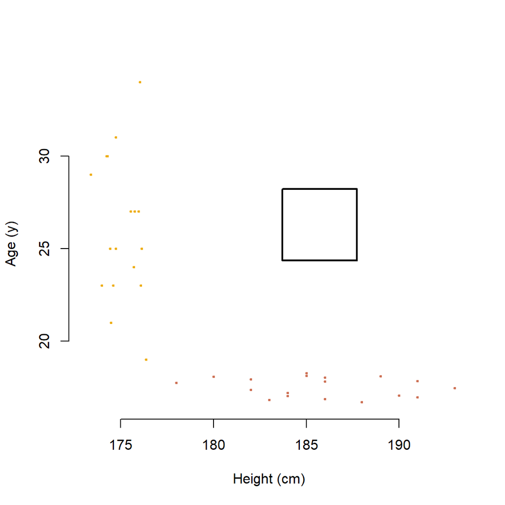

```r
plot.playground(soccer_wrk %>% filter(Position == "Defender") %>% pull(Height),
                soccer_wrk %>% filter(Position == "Defender") %>% pull(Age),
                square = TRUE)
```

С какой вероятностью доверительный квадр покроет точку (реальный средний рост, реальный средний возраст)?

# Итак, два интервала

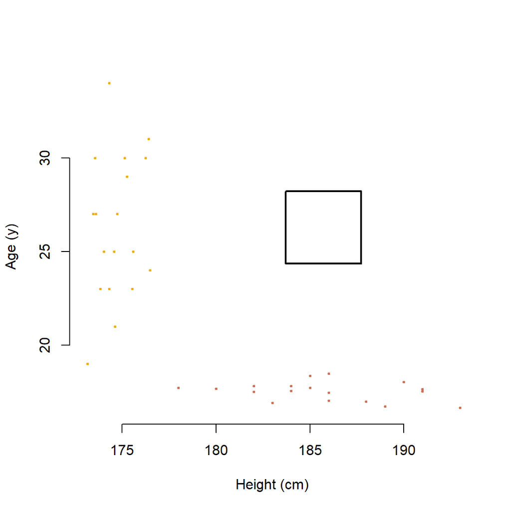

```r
plot.playground(soccer_wrk %>% filter(Position == "Defender") %>% pull(Height),
                soccer_wrk %>% filter(Position == "Defender") %>% pull(Age),
                square = TRUE)
```

С какой вероятностью доверительный квадр покроет точку (реальный средний рост; реальный средний возраст)?

$0.95 \cdot 0.95 = 0.9025 < 0.95$ – в случае независимых интервалов; в общем случае – сложно сказать.

# Итак, два интервала

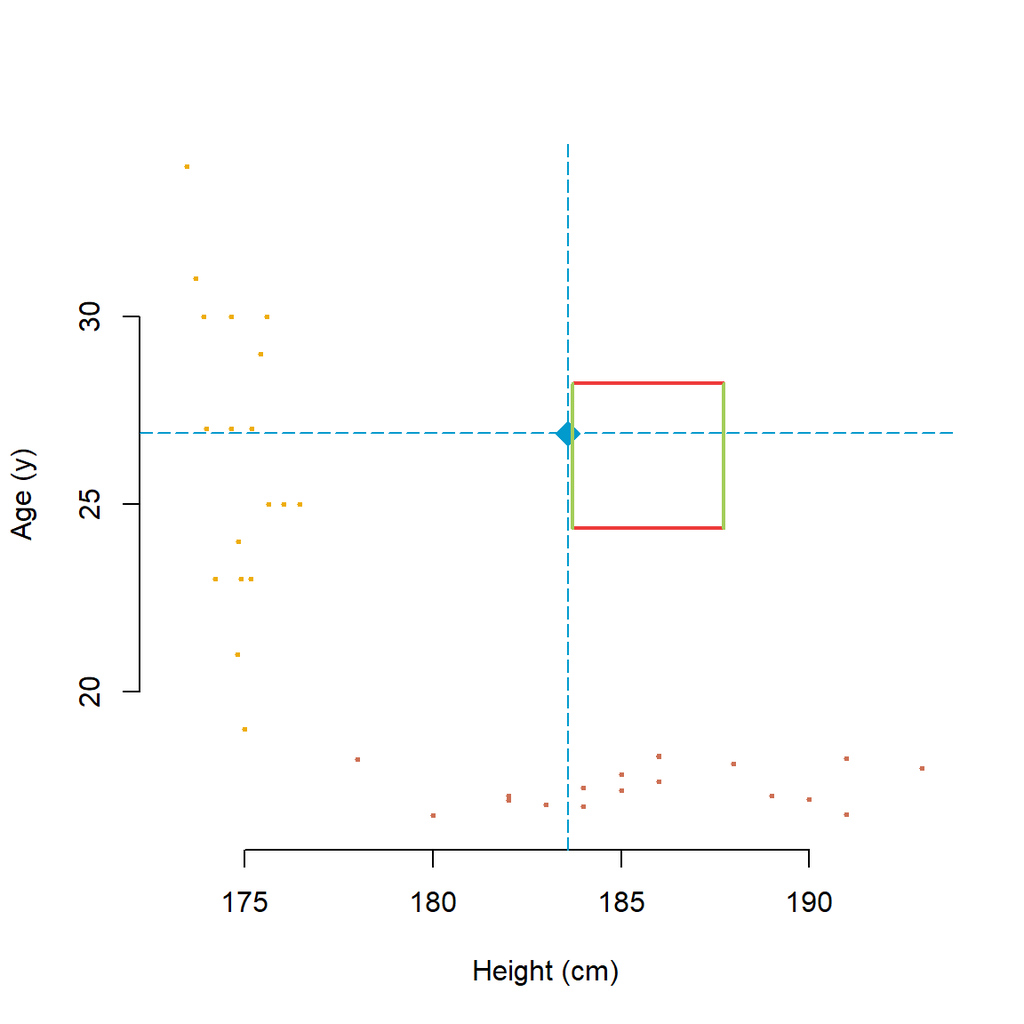

```r
plot.playground(soccer_wrk %>% filter(Position == "Defender") %>% pull(Height),
  soccer_wrk %>% filter(Position == "Defender") %>% pull(Age),
  soccer_general %>% filter(Position == "Defender") %>%
    pull(Height) %>% mean(na.rm = TRUE),
  soccer_general %>% filter(Position == "Defender") %>%
    pull(Age) %>% mean(na.rm = TRUE),
  square = TRUE
)
```

С какой вероятностью доверительный квадр покроет точку (реальный средний рост; реальный средний возраст)?

$0.95 \cdot 0.95 = 0.9025 < 0.95$ – в случае независимых интервалов; в общем случае – сложно сказать.

# А что если интервалов больше? Family-Wise Error Rate

Вероятность покрытия квадром (n интервалов, каждый должен “попасть”): $(1-\alpha)^n$.

Вероятность “осечки” квадра (хотя бы один интервал “промахнулся”) aka FWER: $1 - (1-\alpha)^n$

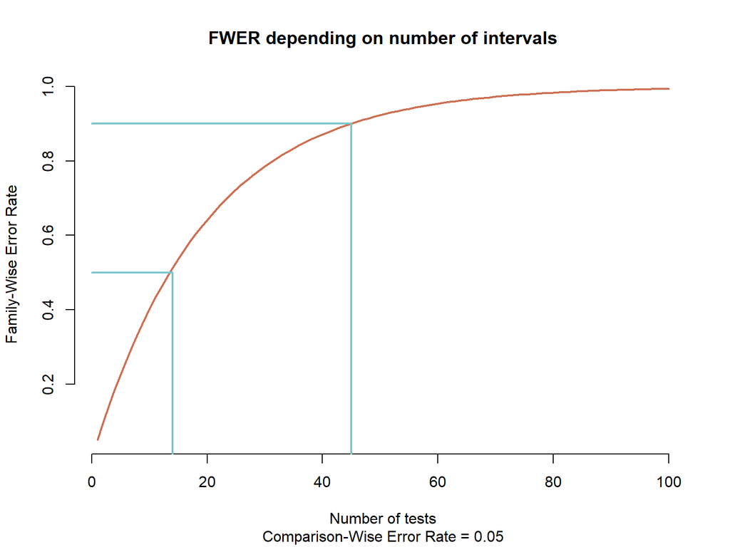

# Часть 2. “Слепила из того, что было”. Два подхода к решению проблемы.

# FWER – как из многих доверительных интервалов “слепить” доверительную область.

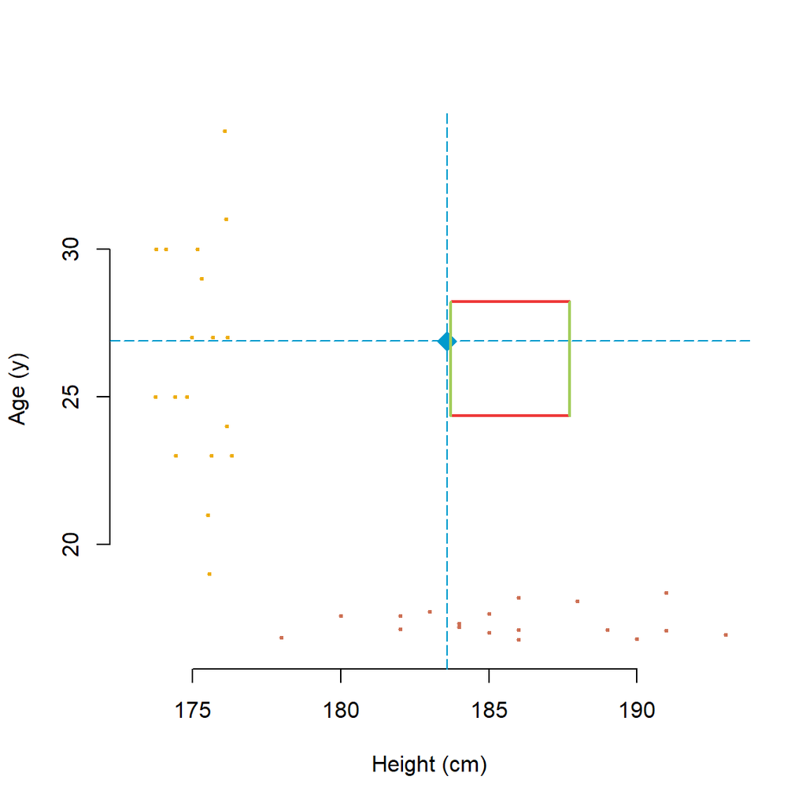

Мы имеем семейство из двух интервалов – два сравнения – и мы хотим контролировать “общую” ошибку первого рода.

- Ошибка первого рода – “доверительный квадр” “промахнулся” => FWER.
- Квадр “промахивается” тогда, когда хотя бы один из интервалов “промахивается”.

Как добиться: поправить CWER (т.е. $\alpha$) так, чтобы FWER = 0.05

# FWER – как из многих доверительных интервалов “слепить” доверительную область.

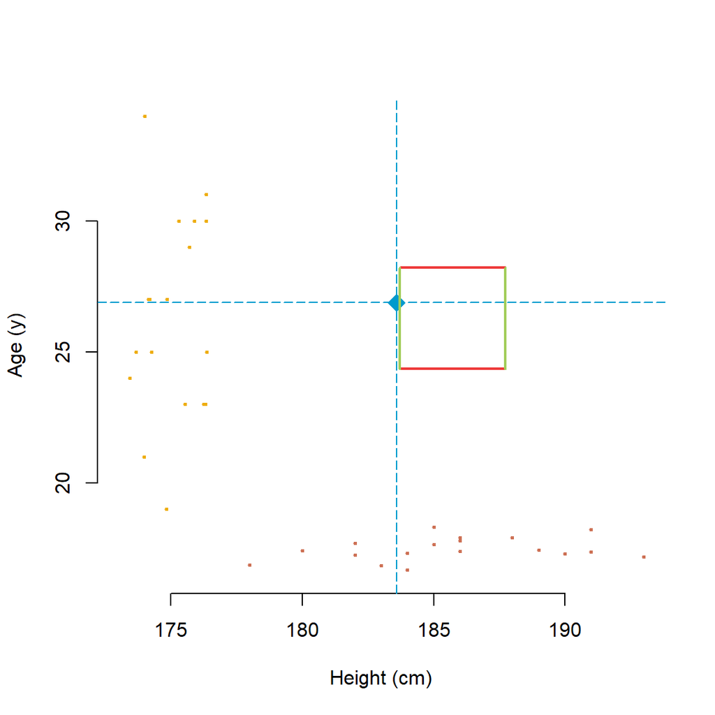

Как добиться: поправить CWER (т.е. $\alpha$) так, чтобы FWER = 0.05

Мы “поправляем” $\alpha$ – отсюда название для таких процедур – поправки на множественные сравнения (multiple comparison correction).

Результат поправки: $\alpha_{adj}$, adjusted $\alpha$, поправленное альфа.

Интервалы, построенные с вероятностью покрытия $1 - \alpha_{adj}$: simultaneous CI.

# FWER. Поправка Бонферрони.

Пусть мы хотим построить $n$ интервалов с $FWER = \alpha$.

Бонферрони предлагает: $CWER = \alpha_{adj} := \alpha/n$. Такая процедура гарантирует, что $FWER <= 0.05$.

**В нашем случае:**

- Хотим квадр для роста и возраста защитников с вероятностью “осечки” $\alpha = 0.05 = FWER$.
- Вероятность покрытия для квадра тогда…

# FWER. Поправка Бонферрони. Пример.

Пусть мы хотим построить $n$ интервалов с $FWER = \alpha$.

Бонферрони предлагает: $CWER = \alpha_{adj} := \alpha/n$. Такая процедура гарантирует, что $FWER <= 0.05$.

**В нашем случае:**

- Хотим квадр для роста и возраста защитников с вероятностью “осечки” $\alpha = 0.05 = FWER$.
  - Вероятность покрытия для квадра тогда $1- \alpha = 1-FWER = 0.95$. 95% квадр.
- Чему должен быть равен CWER по Бонферрони?

# FWER. Поправка Бонферрони. Пример.

Пусть мы хотим построить $n$ интервалов с $FWER = \alpha$.

Бонферрони предлагает: $CWER = \alpha_{adj} := \alpha/n$. Такая процедура гарантирует, что $FWER <= 0.05$.

**В нашем случае:**

- Хотим квадр для роста и возраста защитников с вероятностью “осечки” $\alpha = 0.05 = FWER$.
  - Вероятность покрытия для квадра тогда $1- \alpha = 1-FWER = 0.95$. 95% квадр.
- Чему должен быть равен CWER по Бонферрони?
  - $\alpha_{adj} = 0.05/2 = 0.025$
  - Отдельные интервалы имеют вероятность покрытия $1-0.025=0.975$.

# FWER. Поправка Бонферрони. Пример.

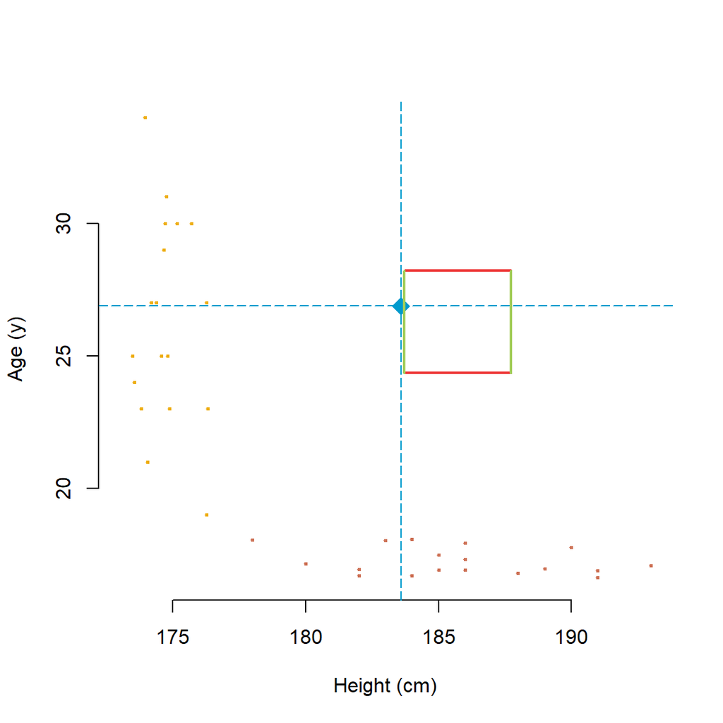

**В нашем случае:**

- Хотим квадр для роста и возраста защитников с вероятностью “осечки” $\alpha = 0.05 = FWER$.
  - Вероятность покрытия для квадра тогда $1- \alpha = 1-FWER = 0.95$. 95% квадр.
- Чему должен быть равен CWER по Бонферрони?
  - $\alpha_{adj} = 0.05/2 = 0.025$
  - Отдельные интервалы имеют вероятность покрытия $1-0.025=0.975$.

# FWER. Поправка Бонферрони. Пример.

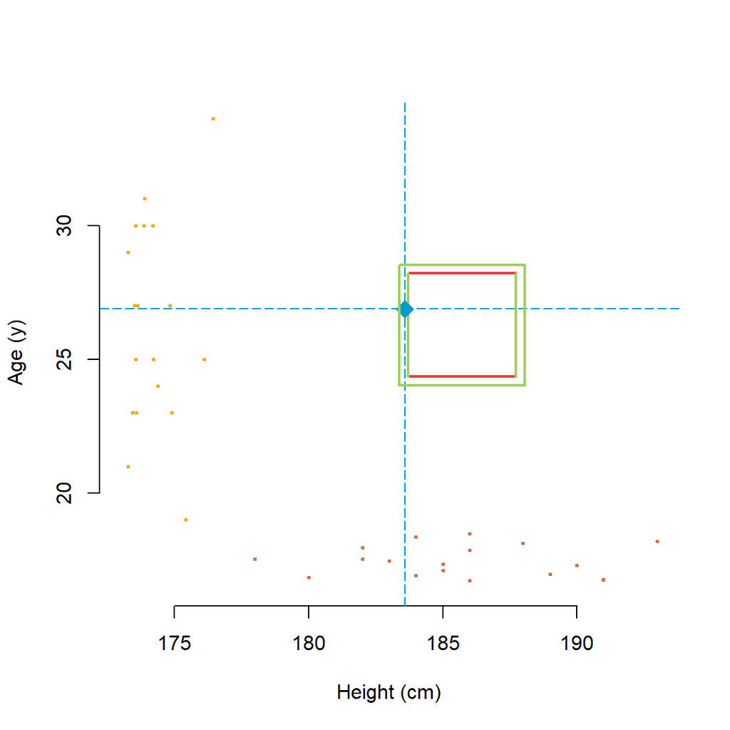

**В нашем случае:**

- Хотим квадр для роста и возраста защитников с вероятностью “осечки” $\alpha = 0.05 = FWER$.
  - Вероятность покрытия для квадра тогда $1- \alpha = 1-FWER = 0.95$. 95% квадр.
- Чему должен быть равен CWER по Бонферрони?
  - $\alpha_{adj} = 0.05/2 = 0.025$
  - Отдельные интервалы имеют вероятность покрытия $1-0.025=0.975$.

# FWER. Поправка Бонферрони на языке p-values.

Поправку Бонферрони мы можем использовать и в контексте тестирования. Поправлять будем p-values, в результате получим *adjusted p-values*, $p_{adj}$.

$p^{adj}_i := n \cdot p_i$

# FWER. Поправка Бонферрони на языке p-values. Пример.

Средний возраст защитника в генеральной совокупности:

```r
soccer_general %>% filter(Position == "Defender") %>% pull(Age) %>% mean(na.rm = TRUE)
```

```
## [1] 26.88427
```

Средний рост защитника в генеральной совокупности:

```r
soccer_general %>% filter(Position == "Defender") %>% pull(Height) %>% mean(na.rm = TRUE)
```

```
## [1] 183.586
```

# FWER. Поправка Бонферрони на языке p-values. Пример.

```r
soccer_wrk %>% filter(Position == "Defender") %>% select(Age) %>% t.test(mu = 26.88)
```

```
##
##  One Sample t-test
##
## data:  .
## t = -0.65891, df = 17, p-value = 0.5188
## alternative hypothesis: true mean is not equal to 26.88
## 95 percent confidence interval:
##  24.34948 28.20607
## sample estimates:
## mean of x
##  26.27778
```

```r
soccer_wrk %>% filter(Position == "Defender") %>% select(Height) %>% t.test(mu = 183.57)
```

```
##
##  One Sample t-test
##
## data:  .
## t = 2.2596, df = 17, p-value = 0.03727
## alternative hypothesis: true mean is not equal to 183.57
## 95 percent confidence interval:
##  183.7127 187.7318
## sample estimates:
## mean of x
##  185.7222
```

# FWER. Поправка Бонферрони на языке p-values. Пример.

Поправлять будем p-values, в результате получим *adjusted p-values*, $p_{adj}$.

$p^{adj}_i := n \cdot p_i$

- Возраст: $p_1 = 0.5188$
- Рост: $p_2 = 0.03727$

# FWER. Поправка Бонферрони на языке p-values. Пример.

Поправлять будем p-values, в результате получим *adjusted p-values*, $p_{adj}$.

$p^{adj}_i := n \cdot p_i$

- Возраст: $p_1 = 0.5188$, $p_1^{adj} = 1$
- Рост: $p_2 = 0.03727$, $p_2^{adj} = 0.07454$

# FWER. Поправка Бонферрони на языке p-values. Пример.

Поправлять будем p-values, в результате получим *adjusted p-values*, $p_{adj}$.

$p^{adj}_i := n \cdot p_i$

- Возраст: $p_1 = 0.5188$, $p_1^{adj} = 1$
- Рост: $p_2 = 0.03727$, $p_2^{adj} = 0.07454$

```r
p.adjust(c(0.5188, 0.03727), method = "bonferroni")
```

```
## [1] 1.00000 0.07454
```

# No Free Sandwich: чем расплачиваемся?

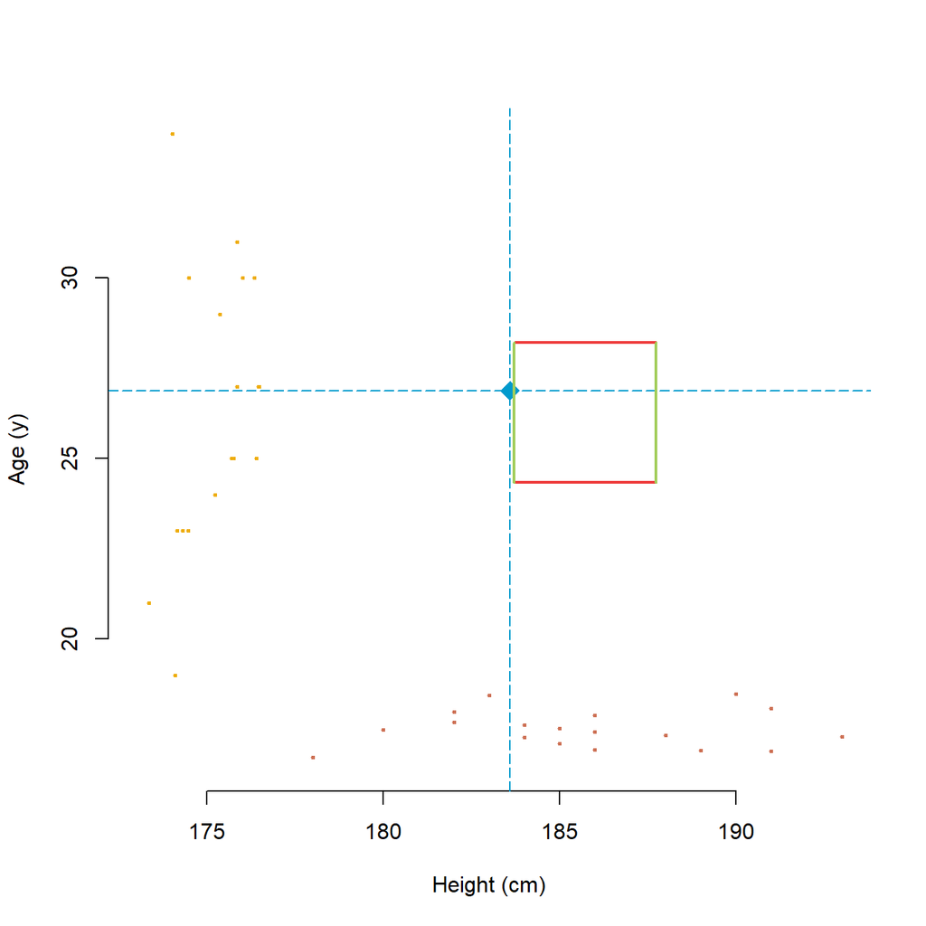

- Любая поправка снижает CWER. Какой у этого побочный эффект?

# No Free Sandwich: чем расплачиваемся?

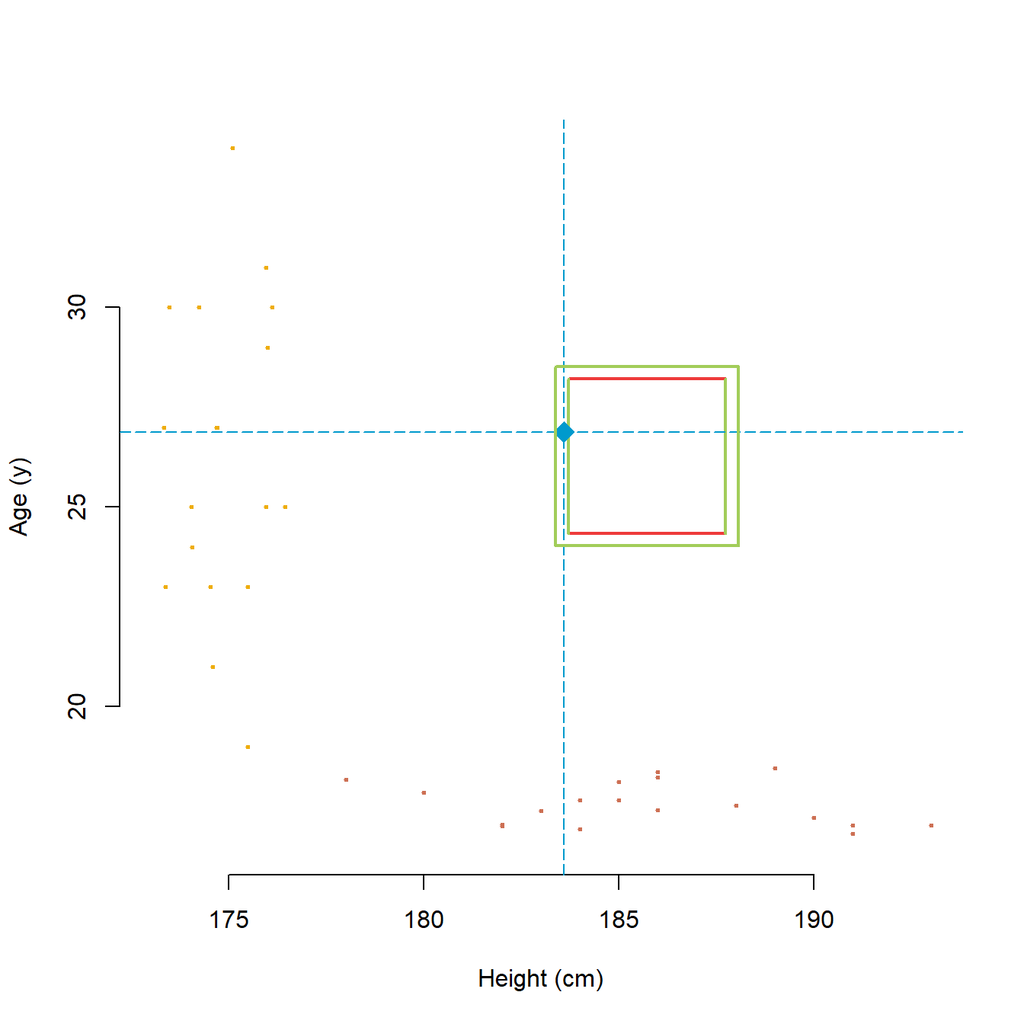

- Любая поправка снижает CWER. Какой у этого побочный эффект?
  - Увеличение вероятности ошибки второго рода aka удлинение интервалов по отдельности.

# No Free Sandwich: чем расплачиваемся?

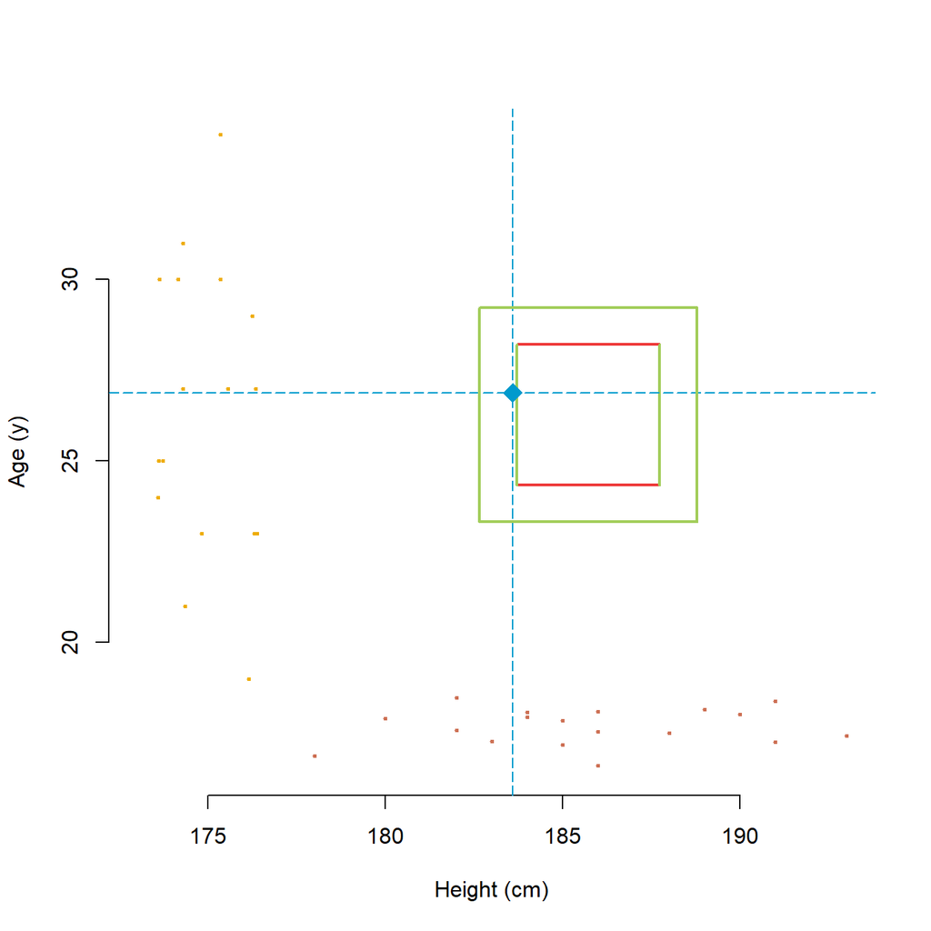

- Любая поправка снижает CWER. Какой у этого побочный эффект?
  - Увеличение вероятности ошибки второго рода aka удлинение интервалов по отдельности.
  - Конкретно Бонферрони очень консервативен. Т.е. для большого количества тестов $CWER << 0.05$, вероятность ошибки второго рода (длины интервалов) очень большие.

*– Не подскажете, где вход в метро?*

*– Где-то в Евразии.*

# No Free Sandwich: чем расплачиваемся?

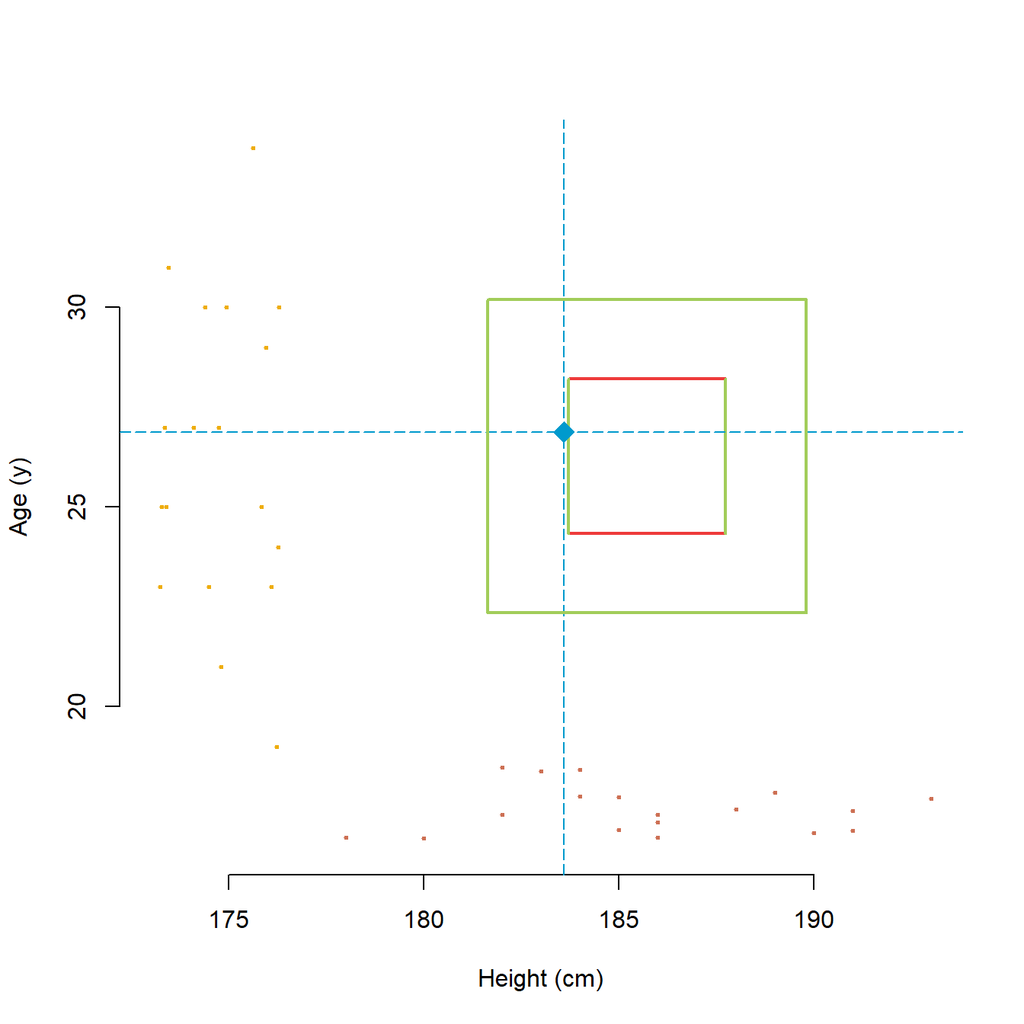

- Любая поправка снижает CWER. Какой у этого побочный эффект?
  - Увеличение вероятности ошибки второго рода aka удлинение интервалов по отдельности.
  - Конкретно Бонферрони очень консервативен. Т.е. для большого количества тестов $FWER << 0.05$, вероятность ошибки второго рода (длины интервалов) очень большие.

*– Не подскажете, где вход в метро?*

*– Где-то в Евразии.*

# No Free Sandwich: чем расплачиваемся?

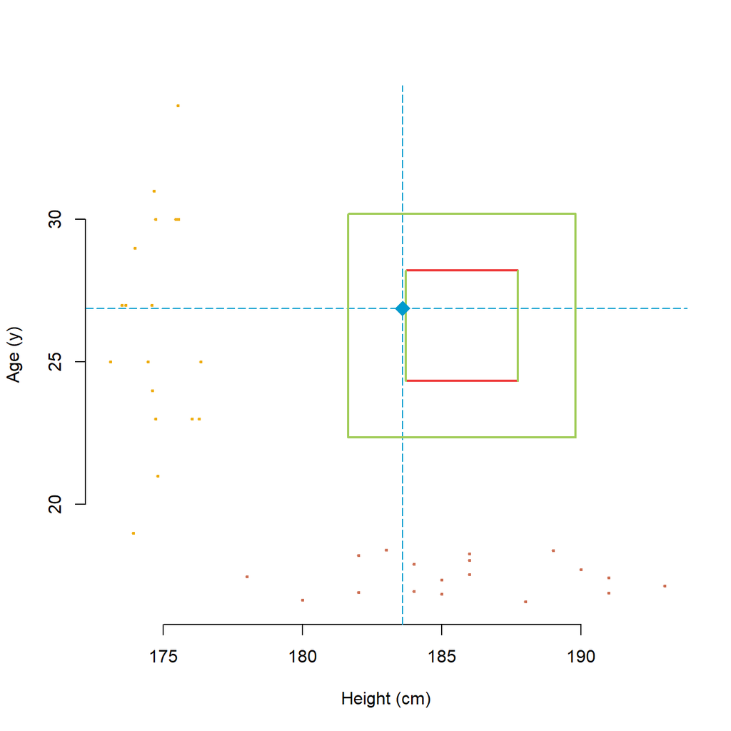

- Любая поправка снижает CWER. Какой у этого побочный эффект?
  - Увеличение вероятности ошибки второго рода aka удлинение интервалов по отдельности.
  - Конкретно Бонферрони очень консервативен. Т.е. для большого количества тестов $FWER << 0.05$, вероятности ошибки второго рода (длины интервалов) очень большие.

*– Не подскажете, где вход в метро?*

*– Где-то в Евразии.*

Заметим: $p_{adj} = min(1, n\cdot p) \rightarrow 1$ при $n \rightarrow \infty$, т.е. нулевая гипотеза (почти) никогда не будет отвергнута.

Также заметим: $1- \frac{\alpha}{n} \rightarrow 1$ при $n \rightarrow 1$, т.е. отдельный интервал почти всегда покроет реальное значение – ценой большой длины.

# No Free Sandwich: чем расплачиваемся?

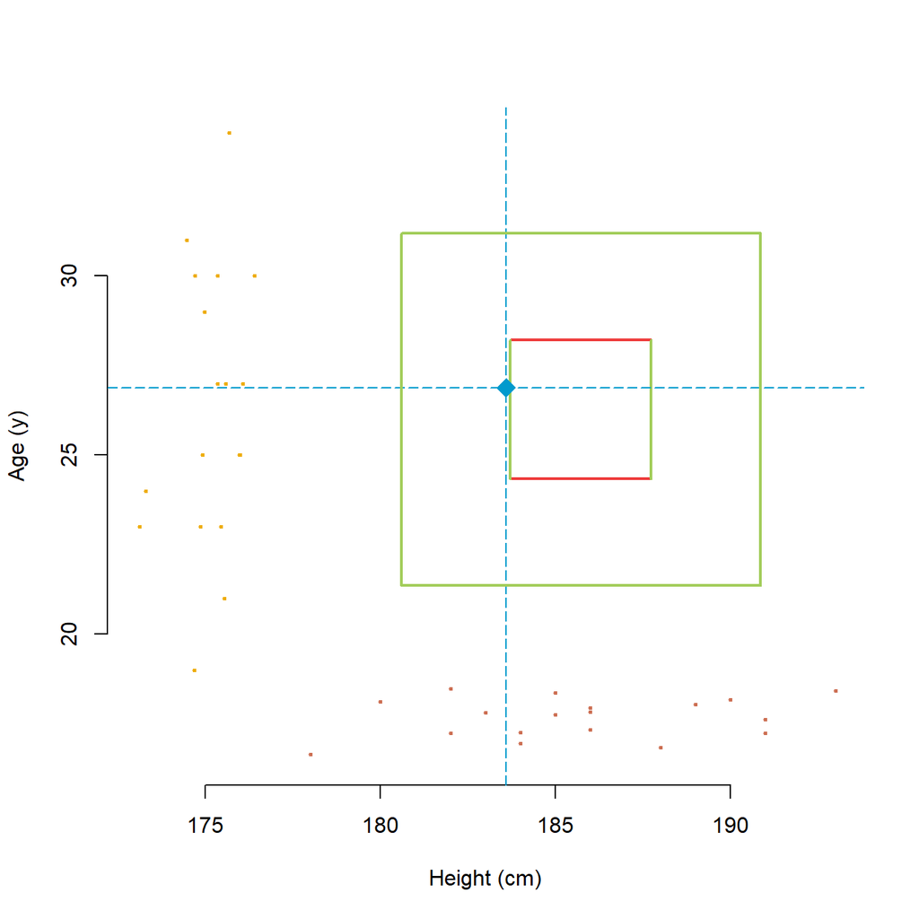

- Любая поправка снижает CWER. Какой у этого побочный эффект?
  - Увеличение вероятности ошибки второго рода aka удлинение интервалов по отдельности.
  - Конкретно Бонферрони очень консервативен. Т.е. для большого количества тестов $FWER << 0.05$, вероятности ошибки второго рода (длины интервалов) очень большие.

*– Не подскажете, где вход в метро?*

*– Где-то в Евразии.*

Заметим: $p_{adj} = min(1, n\cdot p) \rightarrow 1$ при $n \rightarrow \infty$, т.е. нулевая гипотеза (почти) никогда не будет отвергнута.

Также заметим: $1- \frac{\alpha}{n} \rightarrow 1$ при $n \rightarrow 1$, т.е. отдельный интервал почти всегда покроет реальное значение – ценой большой длины.

# No Free Sandwich: чем расплачиваемся?

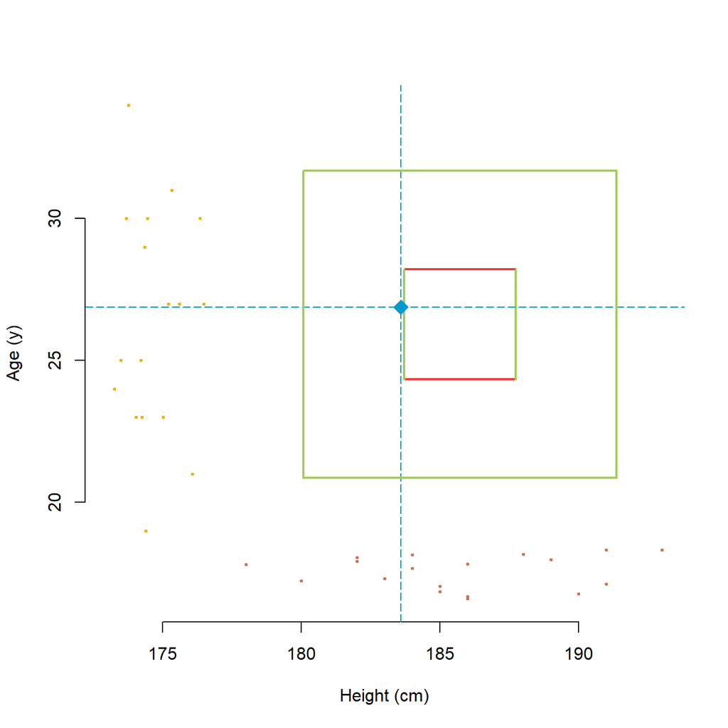

- Любая поправка снижает CWER. Какой у этого побочный эффект?
  - Увеличение вероятности ошибки второго рода aka удлинение интервалов по отдельности.
  - Конкретно Бонферрони очень консервативен. Т.е. для большого количества тестов $FWER << 0.05$, вероятности ошибки второго рода (длины интервалов) очень большие.
- Существуют альтернативные поправки: Шидак, Симс, Шеффе, Хохберг (не путать с Бенджамини-Хохбергом!) и т.д.
  - Не очень популярны, на практике для контроля FWER все обычно используют Бонферрони (или Холма).
  - Обращайте внимание на условия применимости. Бонферрони бронебоен и универсален, другие поправки могут иметь дополнительные условия (например, Шидак требует независимости тестовых статистик).
  - Бонферрони можно использовать для “склеивания” каких угодно тестов. Некоторые процедуры узкоспециальны (например, ANOVA и post-hoc процедуры к ней).
  - Поправки часто конструировались для тестов. Некоторые из поправок непросто или невозможно перевести на язык доверительных интервалов.

# (Почти) бесплатный тюнинг Бонферрони. Поправка Холма.

В случае, если мы хотим контролировать FWER, но фокусируемся на p-values, а доверительные области/интервалы нас не особо интересуют, мы можем использовать поправку Холма.

- Поправка Холма (как и Бонферрони) контролирует FWER.
- Поправка Холма однако часто более мягкая, чем поправка Бонферрони. Соответственно, тесты имеют большую силу.
- Поправка Холма универсальна, как и Бонферрони: никаких дополнительных требований, можно “склеивать” любые тесты.
- Минус – перевод поправки на язык доверительных интервалов неочевиден.
- Минус – склеивает конкретные тесты вместе, нельзя разделить и пересобрать (обсудим чуть позже).

```r
p.adjust(c(0.5188, 0.03727), method = "bonferroni")
```

```
## [1] 1.00000 0.07454
```

```r
p.adjust(c(0.5188, 0.03727), method = "holm")
```

```
## [1] 0.51880 0.07454
```

# А что если тестов очень много? FDR

Мы можем подойти к обобщению ошибки первого рода с другого конца.

Предположим мы провели 1000 тестов, 100 из которых показали $p<0.05$ – т.е. мы совершили 100 “открытий” (discoveries). Сколько из этих открытий ложные, т.е. сколько ошибок первого рода мы совершили?

Интуитивно мы ожидаем, что процент ложных открытий должен быть в среднем около 5%.

# А что если тестов очень много? FDR

Мы можем подойти к обобщению ошибки первого рода с другого конца.

Предположим мы провели 1000 тестов, 100 из которых показали $p<0.05$ – т.е. мы совершили 100 “открытий” (discoveries). Сколько из этих открытий ложные, т.е. сколько ошибок первого рода мы совершили?

Интуитивно мы ожидаем, что процент ложных открытий должен быть в среднем около 5%.

*Ожидаемая* доля *ложных* открытий от *всех* открытий называется False Discovery Rate (FDR). Мы можем контролировать FDR вместо FWER – обычно это приводит к более мягким поправкам и, соответственно, более сильным тестам. Зачастую более разумно контролировать FDR вместо FWER: особенно это касается геномики, протеомики и прочих -ик.

# А что если тестов очень много? FDR

Мы можем подойти к обобщению ошибки первого рода с другого конца.

Предположим мы провели 1000 тестов, 100 из которых показали $p<0.05$ – т.е. мы совершили 100 “открытий” (discoveries). Сколько из этих открытий ложные, т.е. сколько ошибок первого рода мы совершили?

Интуитивно мы ожидаем, что процент ложных открытий должен быть в среднем около 5%.

*Ожидаемая* доля *ложных* открытий от *всех* открытий называется False Discovery Rate (FDR). Мы можем контролировать FDR вместо FWER – обычно это приводит к более мягким поправкам и, соответственно, более сильным тестам. Зачастую более разумно контролировать FDR вместо FWER: особенно это касается геномики, протеомики и прочих -ик.

Самая популярная поправка, которая контролирует FDR – поправка / процедура Бенджамини-Хохберга. **Процедура предполагает независимость проводимых тестов!**

# А что если тестов очень много? FDR

Мы можем подойти к обобщению ошибки первого рода с другого конца.

Предположим мы провели 1000 тестов, 100 из которых показали $p<0.05$ – т.е. мы совершили 100 “открытий” (discoveries). Сколько из этих открытий ложные, т.е. сколько ошибок первого рода мы совершили?

Интуитивно мы ожидаем, что процент ложных открытий должен быть в среднем около 5%.

*Ожидаемая* доля *ложных* открытий от *всех* открытий называется False Discovery Rate (FDR). Мы можем контролировать FDR вместо FWER – обычно это приводит к более мягким поправкам и, соответственно, более сильным тестам. Зачастую более разумно контролировать FDR вместо FWER: особенно это касается геномики, протеомики и прочих -ик.

Самая популярная поправка, которая контролирует FDR – поправка / процедура Бенджамини-Хохберга. **Процедура предполагает независимость тестируемых гипотез!**

```r
p.adjust(c(0.5188, 0.03727), method = "BH")
```

```
## [1] 0.51880 0.07454
```

# Применение поправок. Практические рекомендации.

- Проводить только те тесты, которые действительно нужны/важны и применять поправки к ним.
  - Альтернатива: разумная группировка тестов в “семейства” и применять поправки внутри семейств. Например, сгруппировать тесты по группам пациентов.
  - Если мы исследуем три опросника на трех группах пациентов, можно сделать поправку Бонферрони на три теста, а не на девять. Тогда любые комбинации из трех тестов будут “проконтролированы”. В частности, можно рассматривать три опросника внутри одной группы пациентов или три группы пациентов в рамках одного опросника. (Не работает с Холмом).

# Применение поправок. Практические рекомендации.

Общая логика применения поправок: важно решить, ошибка первого или второго рода более нежелательна и на основании этого выбирать поправку.

- В эксплораторных исследованиях можно применять более мягкие поправки или не применять поправки вообще.
  - Обычно после этого следует конфирматорное исследование, где поправки уже применяются.
  - Сюда же можно отнести геномику и прочие области с 1000+ тестов на одном датасете.
- Обычно поправки не применяются в safety studies – исследование побочных или негативных эффектов.

# Применение поправок. Практические рекомендации.

- FWER как правило обеспечивает более строгий контроль над ошибками первого рода. Его разумно применять в конфирматорных исследованиях.
  - FWER разумно применять, когда нужно проконтролировать все тесты / параметры **вместе**. Пример: бета-блокаторы должны *одновременно* снижать давление и ЧСС.
- FDR дает более мягкий контроль над ошибками первого рода и более низкую вероятность ошибки второго рода. Его разумно использовать при поиске “зацепок” для дальнейших исследований (эксплораторные исследования).
- Иногда пачку тестов с поправками можно заменить одним более сильным тестом (change-point models, Hotelling T-test, AN(C)OVA…). Помните, обычно существует более одного способа подойти к задаче.

# Рекомендованная литература

1. *Controlling the False Discovery Rate: A Practical and Powerful Approach to Multiple Testing* by Yoav Benjamini and Yoav Hochberg.

# Домашнее задание

```r
soccer_general <- read.csv("soccer.csv", sep=";")[, 2:6] %>%
  mutate(Position = as.factor(Position),
         Nationality = as.factor(Nationality),
         Age = as.numeric(Age),
         Height = as.numeric(Height)) %>%
  filter(Nationality %in% c("Spanish", "Italian", "German", "English", "Argentinian"))

set.seed(1)

soccer_wrk <- soccer_general[sample(1:nrow(soccer_general), 150), ] %>%
  mutate(Nationality = factor(Nationality))
```

Есть ли разница между средним ростом футболистов, играющих на разных позициях?

1. Постройте доверительные интервалы для попарных разниц между средними (без поправок и с поправкой Бонферрони). Покрывают ли интервалы реальную разницу между средним ростом? Иллюстрации приветствуются.
2. Проведите попарные тесты для разниц между средними (без поправок, с поправкой Холма и поправкой Бенджамини-Хохберга). Сколько открытий получилось в каждом случае? Сколько из них ложные?

Hint 2: параметр задайте параметр `pool.sd = FALSE`.

Решение в формате html отчета + исходный код.